# Logistical regression

This notebook uses the **Titanic** dataset from [Kaggle](https://www.kaggle.com/c/titanic). The dataset contains details about the passengers on the Titanic. The purpose of the code in the notebook is to find out the probability that passengers survived the sinking of the Titanic. The code uses **logistical regression**, as we are dealing with categorical data (survived/didn’t survive).

## Get the data

```r
library(readr)
library(dplyr)
dfTrain <- read.csv('Machine Learning with R/titanic_train.csv')
head(dfTrain)
```

|  | PassengerId | Survived | Pclass | Name | Sex | Age | SibSp | Parch | Ticket | Fare | Cabin | Embarked |
| --- | --- | --- | --- | --- | --- | --- | --- | --- | --- | --- | --- | --- |
| 1 | 1 | 0 | 3 | Braund, Mr. Owen Harris | male | 22 | 1 | 0 | A/5 21171 | 7.2500 |  | S |
| 2 | 2 | 1 | 1 | Cumings, Mrs. John Bradley (Florence Briggs Thayer) | female | 38 | 1 | 0 | PC 17599 | 71.2833 | C85 | C |
| 3 | 3 | 1 | 3 | Heikkinen, Miss. Laina | female | 26 | 0 | 0 | STON/O2. 3101282 | 7.9250 |  | S |
| 4 | 4 | 1 | 1 | Futrelle, Mrs. Jacques Heath (Lily May Peel) | female | 35 | 1 | 0 | 113803 | 53.1000 | C123 | S |
| 5 | 5 | 0 | 3 | Allen, Mr. William Henry | male | 35 | 0 | 0 | 373450 | 8.0500 |  | S |
| 6 | 6 | 0 | 3 | Moran, Mr. James | male | NA | 0 | 0 | 330877 | 8.4583 |  | Q |

## Exploratory Data Analysis (EDA)

Import the *Amelia* package, which is used to find missing data.

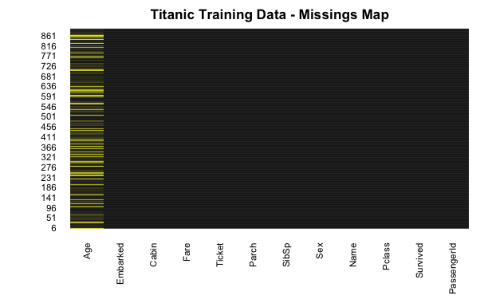

```r
# import the Amelia package
library(Amelia)
missmap(dfTrain, main="Titanic Training Data - Missings Map",
        col=c("yellow", "black"), legend=FALSE)
```

the yellow lines are the datapoints that have an NA value. For instance, the 6th datapoint (i.e. row 6 in the dataframe) has age *NA*.

## Visualize the data

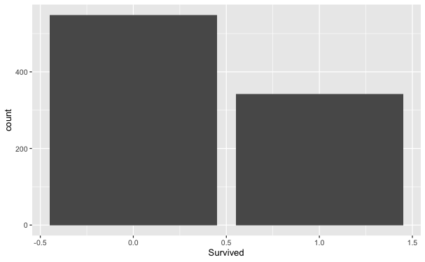

```r
library(ggplot2)
ggplot(dfTrain, aes(Survived)) + geom_bar()
```

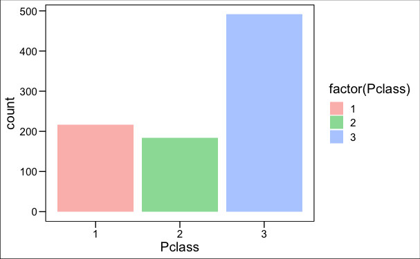

```r
ggplot(dfTrain,aes(Pclass)) + geom_bar(aes(fill=factor(Pclass)),alpha=0.5) + theme_base()
```

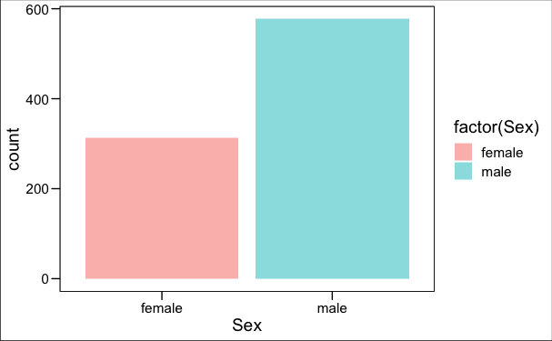

```r
ggplot(dfTrain,aes(Sex)) + geom_bar(aes(fill=factor(Sex)),alpha=0.5) + theme_base()
```

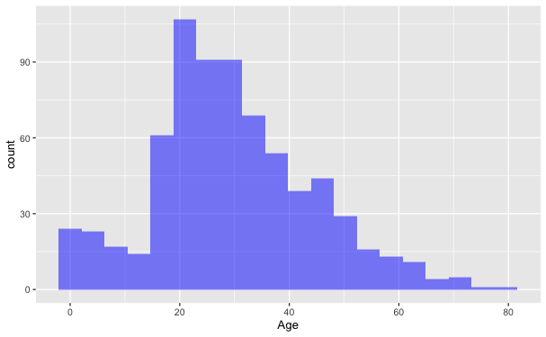

```r
ggplot(dfTrain,aes(Age)) + geom_histogram(fill='blue',bins=20,alpha=0.5)
```

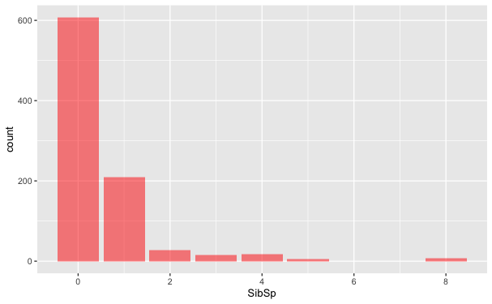

```r
ggplot(dfTrain,aes(SibSp)) + geom_bar(fill='red',alpha=0.5)
```

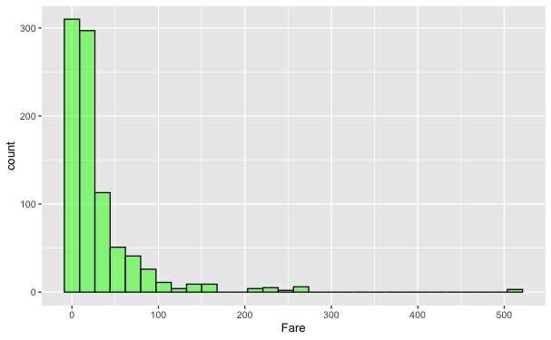

```r
ggplot(dfTrain,aes(Fare)) + geom_histogram(fill='green',color='black',alpha=0.5)
```

## Data Cleaning

We want to fill in missing age data instead of just dropping the missing age data rows. One way to do this is by filling in the mean age of all the passengers (imputation).

However we can be smarter about this and check the average age by passenger class. For example:

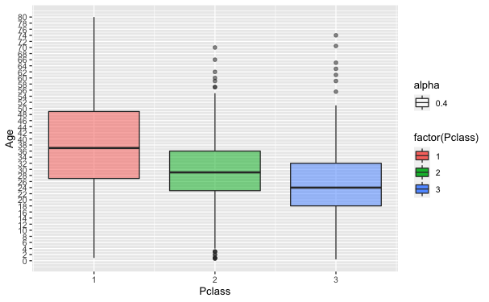

```r
pl <- ggplot(dfTrain,aes(Pclass,Age)) + geom_boxplot(aes(group=Pclass,fill=factor(Pclass),alpha=0.4))
pl + scale_y_continuous(breaks = seq(min(0), max(80), by = 2))
```

We can see from this boxplot that each class of passenger has a different average age (1st class passengers tend to be the oldest, 3rd class passengers the youngest).

```r
impute_age <- function(age,class){
    out <- age
    for (i in 1:length(age)){

        if (is.na(age[i])){

            if (class[i] == 1){
                out[i] <- 37

            }else if (class[i] == 2){
                out[i] <- 29

            }else{
                out[i] <- 24
            }
        }else{
            out[i]<-age[i]
        }
    }
    return(out)
}
```

```r
fixedAges <- impute_age(dfTrain$Age,dfTrain$Pclass)
dfTrain$Age <- fixedAges
```

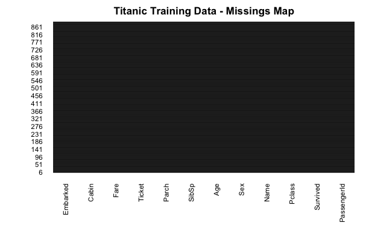

```r
missmap(dfTrain, main="Titanic Training Data - Missings Map",
        col=c("yellow", "black"), legend=FALSE)
```

There is now no missing age data. I’m not sure about this approach of adding in the average for missing values. It assumes that there is the missing values are evenly distributed, but it could be that the missing values were not evenly distributed. There may be a reason why some values are missing: perhaps these people were all elderly and did not want to give their age. If the missing values were not evenly distributed, we could be providing misleading results.

My initial approach was to remove the passengers with missing values from any age-based analysis.

## Building a Logistic Regression Model

Now it is time to build our model! Let’s begin by doing a final “clean-up” of our data by removing the features we won’t be using and making sure that the features are of the correct data type.

```r
str(dfTrain)
```

```
'data.frame':   891 obs. of  12 variables:
 $ PassengerId: int  1 2 3 4 5 6 7 8 9 10 ...
 $ Survived   : int  0 1 1 1 0 0 0 0 1 1 ...
 $ Pclass     : int  3 1 3 1 3 3 1 3 3 2 ...
 $ Name       : Factor w/ 891 levels "Abbing, Mr. Anthony",..: 109 191 358 277 16 559 520 629 417 581 ...
 $ Sex        : Factor w/ 2 levels "female","male": 2 1 1 1 2 2 2 2 1 1 ...
 $ Age        : num  22 38 26 35 35 24 54 2 27 14 ...
 $ SibSp      : int  1 1 0 1 0 0 0 3 0 1 ...
 $ Parch      : int  0 0 0 0 0 0 0 1 2 0 ...
 $ Ticket     : Factor w/ 681 levels "110152","110413",..: 524 597 670 50 473 276 86 396 345 133 ...
 $ Fare       : num  7.25 71.28 7.92 53.1 8.05 ...
 $ Cabin      : Factor w/ 148 levels "","A10","A14",..: 1 83 1 57 1 1 131 1 1 1 ...
 $ Embarked   : Factor w/ 4 levels "","C","Q","S": 4 2 4 4 4 3 4 4 4 2 ...
```

```r
dfTrain <- select(dfTrain,-PassengerId,-Name,-Ticket,-Cabin)
```

```r
str(dfTrain)
```

```
'data.frame':   891 obs. of  8 variables:
 $ Survived: int  0 1 1 1 0 0 0 0 1 1 ...
 $ Pclass  : int  3 1 3 1 3 3 1 3 3 2 ...
 $ Sex     : Factor w/ 2 levels "female","male": 2 1 1 1 2 2 2 2 1 1 ...
 $ Age     : num  22 38 26 35 35 24 54 2 27 14 ...
 $ SibSp   : int  1 1 0 1 0 0 0 3 0 1 ...
 $ Parch   : int  0 0 0 0 0 0 0 1 2 0 ...
 $ Fare    : num  7.25 71.28 7.92 53.1 8.05 ...
 $ Embarked: Factor w/ 4 levels "","C","Q","S": 4 2 4 4 4 3 4 4 4 2 ...
```

```r
dfTrain$Survived <- factor(dfTrain$Survived)
dfTrain$Pclass <- factor(dfTrain$Pclass)
dfTrain$Parch <- factor(dfTrain$Parch)
dfTrain$SibSp <- factor(dfTrain$SibSp)
```

```r
str(dfTrain)
```

```
'data.frame':   891 obs. of  8 variables:
 $ Survived: Factor w/ 2 levels "0","1": 1 2 2 2 1 1 1 1 2 2 ...
 $ Pclass  : Factor w/ 3 levels "1","2","3": 3 1 3 1 3 3 1 3 3 2 ...
 $ Sex     : Factor w/ 2 levels "female","male": 2 1 1 1 2 2 2 2 1 1 ...
 $ Age     : num  22 38 26 35 35 24 54 2 27 14 ...
 $ SibSp   : Factor w/ 7 levels "0","1","2","3",..: 2 2 1 2 1 1 1 4 1 2 ...
 $ Parch   : Factor w/ 7 levels "0","1","2","3",..: 1 1 1 1 1 1 1 2 3 1 ...
 $ Fare    : num  7.25 71.28 7.92 53.1 8.05 ...
 $ Embarked: Factor w/ 4 levels "","C","Q","S": 4 2 4 4 4 3 4 4 4 2 ...
```

## Train the Model

Now let’s train the model!

```r
logModel <- glm(formula=Survived ~ . , family = binomial(link='logit'),data = dfTrain)
```

```r
summary(logModel)
```

```
Call:
glm(formula = Survived ~ ., family = binomial(link = "logit"),
    data = dfTrain)

Deviance Residuals:
    Min       1Q   Median       3Q      Max
-2.8158  -0.6134  -0.4138   0.5808   2.4896

Coefficients:
              Estimate Std. Error z value Pr(>|z|)
(Intercept)  1.845e+01  1.660e+03   0.011 0.991134
Pclass2     -1.079e+00  3.092e-01  -3.490 0.000484 ***
Pclass3     -2.191e+00  3.161e-01  -6.930 4.20e-12 ***
Sexmale     -2.677e+00  2.040e-01 -13.123  < 2e-16 ***
Age         -3.971e-02  8.758e-03  -4.534 5.79e-06 ***
SibSp1       8.135e-02  2.245e-01   0.362 0.717133
SibSp2      -2.897e-01  5.368e-01  -0.540 0.589361
SibSp3      -2.241e+00  7.202e-01  -3.111 0.001862 **
SibSp4      -1.675e+00  7.620e-01  -2.198 0.027954 *
SibSp5      -1.595e+01  9.588e+02  -0.017 0.986731
SibSp8      -1.607e+01  7.578e+02  -0.021 0.983077
Parch1       3.741e-01  2.895e-01   1.292 0.196213
Parch2       3.862e-02  3.824e-01   0.101 0.919560
Parch3       3.655e-01  1.056e+00   0.346 0.729318
Parch4      -1.586e+01  1.055e+03  -0.015 0.988007
Parch5      -1.152e+00  1.172e+00  -0.983 0.325771
Parch6      -1.643e+01  2.400e+03  -0.007 0.994536
Fare         2.109e-03  2.490e-03   0.847 0.397036
EmbarkedC   -1.458e+01  1.660e+03  -0.009 0.992995
EmbarkedQ   -1.456e+01  1.660e+03  -0.009 0.993001
EmbarkedS   -1.486e+01  1.660e+03  -0.009 0.992857
---
Signif. codes:  0 ‘***’ 0.001 ‘**’ 0.01 ‘*’ 0.05 ‘.’ 0.1 ‘ ’ 1

(Dispersion parameter for binomial family taken to be 1)

    Null deviance: 1186.66  on 890  degrees of freedom
Residual deviance:  763.41  on 870  degrees of freedom
AIC: 805.41

Number of Fisher Scoring iterations: 15
```

## Predicting using Test Cases

Let’s make a test set out of our training set, retrain on the smaller version of our training set and check it against the test subset.

```r
library(caTools)
set.seed(101)

split = sample.split(dfTrain$Survived, SplitRatio = 0.70)

finalTrain = subset(dfTrain, split == TRUE)
finalTest = subset(dfTrain, split == FALSE)
```

Now let’s rerun our model on only our final training set:

```r
finalLogModel <- glm(formula=Survived ~ . , family = binomial(link='logit'),data = finalTrain)
```

```r
summary(finalLogModel)
```

```
Call:
glm(formula = Survived ~ ., family = binomial(link = "logit"),
    data = finalTrain)

Deviance Residuals:
    Min       1Q   Median       3Q      Max
-2.8288  -0.5607  -0.4096   0.6174   2.4898

Coefficients:
              Estimate Std. Error z value Pr(>|z|)
(Intercept)  1.777e+01  2.400e+03   0.007 0.994091
Pclass2     -1.230e+00  3.814e-01  -3.225 0.001261 **
Pclass3     -2.160e+00  3.841e-01  -5.624 1.87e-08 ***
Sexmale     -2.660e+00  2.467e-01 -10.782  < 2e-16 ***
Age         -3.831e-02  1.034e-02  -3.705 0.000212 ***
SibSp1      -2.114e-02  2.755e-01  -0.077 0.938836
SibSp2      -4.000e-01  6.463e-01  -0.619 0.536028
SibSp3      -2.324e+00  8.994e-01  -2.584 0.009765 **
SibSp4      -1.196e+00  8.302e-01  -1.440 0.149839
SibSp5      -1.603e+01  9.592e+02  -0.017 0.986666
SibSp8      -1.633e+01  1.004e+03  -0.016 0.987019
Parch1       7.290e-01  3.545e-01   2.056 0.039771 *
Parch2       1.406e-01  4.504e-01   0.312 0.754892
Parch3       7.919e-01  1.229e+00   0.645 0.519226
Parch4      -1.498e+01  1.552e+03  -0.010 0.992300
Parch5      -9.772e-03  1.378e+00  -0.007 0.994343
Parch6      -1.635e+01  2.400e+03  -0.007 0.994563
Fare         3.128e-03  3.091e-03   1.012 0.311605
EmbarkedC   -1.398e+01  2.400e+03  -0.006 0.995353
EmbarkedQ   -1.387e+01  2.400e+03  -0.006 0.995386
EmbarkedS   -1.431e+01  2.400e+03  -0.006 0.995243
---
Signif. codes:  0 ‘***’ 0.001 ‘**’ 0.01 ‘*’ 0.05 ‘.’ 0.1 ‘ ’ 1

(Dispersion parameter for binomial family taken to be 1)

    Null deviance: 829.60  on 622  degrees of freedom
Residual deviance: 530.63  on 602  degrees of freedom
AIC: 572.63

Number of Fisher Scoring iterations: 15
```

```r
fittedProbabilities <- predict(finalLogModel,newdata=finalTest,type='response')
```

```r
fittedResults <- ifelse(fittedProbabilities > 0.5,1,0)
```

```r
misClasificError <- mean(fittedResults != finalTest$Survived)
print(paste('Accuracy',1-misClasificError))
```

```
[1] "Accuracy 0.798507462686567"
```

The model can make a prediction with almost 80% accuracy. That’s pretty good- much better than chance.

Show the confusion matrix:

```r
confusionMatrix <- table(finalTest$Survived, fittedProbabilities > 0.5)
confusionMatrix
```

```
    FALSE TRUE
  0   140   25
  1    29   74
```

```r
class(confusionMatrix)
```

```
[1] "table"
```